# Comparison of TE insertions found on samples Gemelos_24-512 and Gemelos_23-169

# Distribution per chromosome

## Sample 1

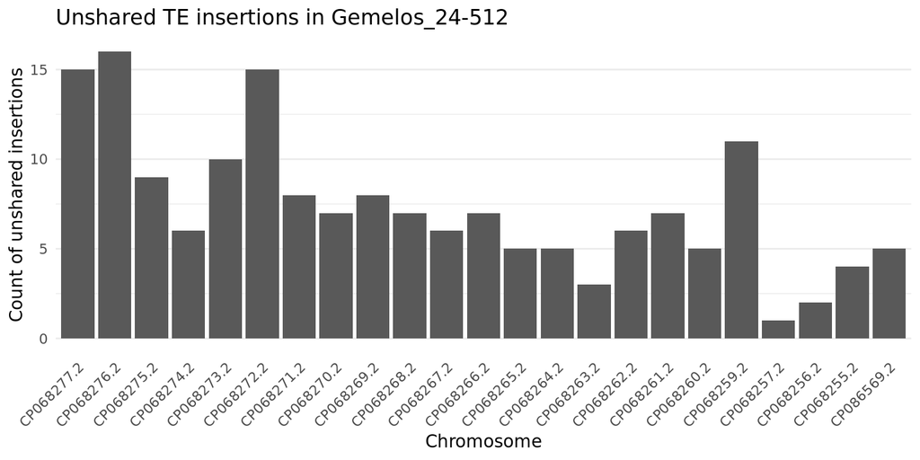

## Sample 2

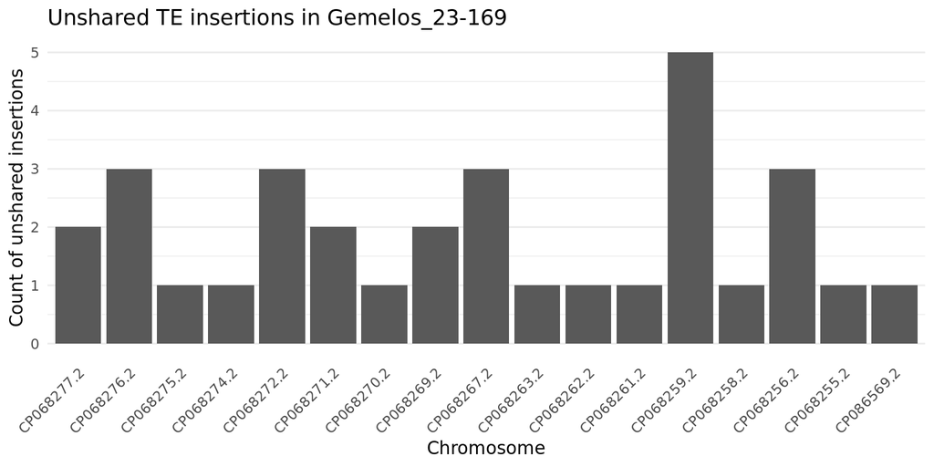

# Shared insertions

With the same methodology than the one used for unshared insertions (checking also for calls that did not pass the strict criterion), 1 859 are reported as shared between both samples.

## Shared insertions by class

| Class | Family | Subfamily | Number of insertions |
| --- | --- | --- | --- |
| Class I | DNA | TcMar | 6 |
|  |  | hAT | 4 |
| Class II | LINE | L1 | 215 |
|  |  | L2 | 5 |
|  | LTR | ERVL | 18 |
|  |  | ERV1 | 76 |
|  |  | ERVK | 12 |
|  | Retroposon | SVA | 214 |
|  | SINE | Alu | 1 307 |
|  |  | MIR | 2 |
| Total | - | - | 1 859 |

## Annotation of shared insertions

In the table below is shown the gene annotation for shared insertions.

**Click to show table with 1 126 rows.**

**Note**: Annotation type is as described by R package annotatr: “cds”: coding sequences, “promoter”: regulatory region up to 1kb uptream, “1to5kb”: regulatory region between 1 and 5kb upstream, “genes” and “introns”: literal meaning.

| Position | INS Id | Gene symbol | Gene Id | Annotation type |
| --- | --- | --- | --- | --- |
| CP068255.2:1 234 402 | seq86734 | SLC25A6 | NM_001636.4 | introns |
| CP068255.2:22 237 816 | seq87171 | PTCHD1-AS | NR_073010.2 | introns |
| CP068255.2:24 293 369 | seq87205 | POLA1 | XM_054327253.1 | introns |
| CP068255.2:31 581 182 | seq87369 | DMD | NM_004013.3 | introns |
| CP068255.2:32 882 843 | seq87410 | DMD | NM_000109.4 | introns |
| CP068255.2:83 656 504 | seq88085 | SATL1 | NM_001367857.2 | introns |
| CP068255.2:83 683 173 | seq88087 | ZNF711 | NM_001330574.2 | introns |
| CP068255.2:84 713 986 | seq88100 | DACH2 | XM_054326429.1 | introns |
| CP068255.2:90 623 038 | seq88234 | PCDH11X | NM_032968.5 | introns |
| CP068255.2:100 344 903 | seq88382 | ZMAT1 | NM_001011657.4 | introns |
| CP068255.2:120 735 396 | seq88725 | LOC101928359 | XR_007091085.1 | introns |
| CP068255.2:145 121 988 | seq89183 | LOC101928832 | XR_007091121.1 | introns |
| CP068255.2:247 895 | seq86600 | LOC102724521 | XR_008485519.1 | introns |
| CP068255.2:295 108 | seq86609 | LOC102724521 | XR_008485519.1 | introns |
| CP068256.2:7 583 739 | seq84582 | LOC128966699 | XR_008485442.1 | promoters |
| CP068256.2:18 235 398 | seq85300 | SLC25A18 | NM_001303484.2 | introns |
|  |  | LOC105372850 | XR_007090425.1 | introns |
| CP068256.2:18 700 162 | seq85317 | LINC01634 | NR_024417.1 | promoters |
| CP068256.2:20 929 750 | seq85425 | MED15 | XM_054325685.1 | introns |
| CP068256.2:24 409 917 | seq85559 | GSTT4 | XM_054325478.1 | introns |
| CP068256.2:25 461 789 | seq85593 | KIAA1671 | NM_001386930.1 | introns |
| CP068256.2:25 532 879 | seq85600 | KIAA1671 | NM_001386930.1 | introns |
| CP068256.2:27 234 737 | seq85662 | MIATNB | NR_110543.1 | introns |
| CP068256.2:28 841 478 | seq85695 | TTC28 | NM_001393404.1 | introns |
| CP068256.2:29 242 941 | seq85702 | CCDC117 | NM_001284263.2 | introns |
| CP068256.2:32 056 349 | seq85761 | SFI1 | NM_001258325.1 | introns |
| CP068256.2:32 056 357 | seq85762 | SFI1 | NM_001258325.1 | introns |
| CP068256.2:32 276 540 | seq85767 | DEPDC5 | XM_054326198.1 | introns |
| CP068256.2:34 820 706 | seq85838 | LOC105373012 | XR_007090622.1 | promoters |
| CP068256.2:35 243 538 | seq85863 | LINC02885 | NR_138042.1 | introns |

[output cut: 1096 more lines]

## Full list

This is the list of insertions found shared between both samples, alongside its allele frequency inside the whole population (all the cases in your pipeline) and which sample it was found in.

| Position | seqId | Length (bp) | Type | Population allele frequency | Present in sample |
| --- | --- | --- | --- | --- | --- |
| CP068255.2:1 234 402 | seq86734 | 119 | SINE (AluJb) | 0.50 | Gemelos_23-169 |
| CP068255.2:3 778 903 | seq86836 | 57 | LINE (L1PB1) | 1.00 | Gemelos_24-512 |
| CP068255.2:5 204 622 | seq86885 | 343 | SINE (AluYa5) | 0.50 | Gemelos_23-169 |
| CP068255.2:22 237 816 | seq87171 | 315 | SINE (AluY) | 1.00 | Gemelos_24-512 |
| CP068255.2:24 293 369 | seq87205 | 129 | Retroposon (SVA_F) | 1.00 | Gemelos_23-169 |
| CP068255.2:25 517 583 | seq87235 | 333 | SINE (AluYb8) | 1.00 | Gemelos_24-512 |
| CP068255.2:25 603 542 | seq87239 | 110 | LINE (L1M3) | 0.50 | Gemelos_23-169 |
| CP068255.2:27 034 647 | seq87275 | 90 | LTR (MER61C) | 0.50 | Gemelos_24-512 |
| CP068255.2:30 241 729 | seq87339 | 333 | SINE (AluY) | 0.50 | Gemelos_23-169 |
| CP068255.2:31 581 182 | seq87369 | 315 | SINE (AluY) | 1.00 | Gemelos_24-512 |
| CP068255.2:32 882 843 | seq87410 | 308 | SINE (AluY) | 0.50 | Gemelos_23-169 |
| CP068255.2:33 005 650 | seq87417 | 6 099 | LINE (L1HS) | 0.25 | Gemelos_24-512 |
| CP068255.2:45 336 178 | seq87582 | 249 | LINE (L1M5) | 0.50 | Gemelos_23-169 |
| CP068255.2:45 683 115 | seq87595 | 125 | Retroposon (SVA_F) | 1.00 | Gemelos_24-512 |
| CP068255.2:52 216 963 | seq87688 | 324 | SINE (AluYb8) | 1.00 | Gemelos_23-169 |
| CP068255.2:56 310 479 | seq87750 | 309 | LINE (L1P2) | 1.00 | Gemelos_24-512 |
| CP068255.2:56 311 246 | seq87751 | 122 | LINE (L1P1) | 1.00 | Gemelos_23-169 |
| CP068255.2:65 312 828 | seq87825 | 122 | LINE (L2a) | 1.00 | Gemelos_24-512 |
| CP068255.2:69 349 478 | seq87894 | 338 | SINE (AluYb8) | 0.50 | Gemelos_23-169 |
| CP068255.2:78 249 308 | seq87984 | 294 | SINE (AluYa5) | 0.50 | Gemelos_24-512 |
| CP068255.2:78 421 263 | seq87992 | 460 | LINE (L1P3) | 0.50 | Gemelos_23-169 |
| CP068255.2:82 985 846 | seq88065 | 1 755 | LINE (L1M1) | 0.25 | Gemelos_24-512 |
| CP068255.2:83 038 218 | seq88067 | 351 | LINE (L1PB) | 0.50 | Gemelos_23-169 |
| CP068255.2:83 656 504 | seq88085 | 86 | LINE (L1MC5) | 1.00 | Gemelos_24-512 |
| CP068255.2:83 683 173 | seq88087 | 329 | SINE (AluY) | 0.75 | Gemelos_23-169 |
| CP068255.2:84 713 986 | seq88100 | 311 | SINE (AluYa5) | 1.00 | Gemelos_24-512 |
| CP068255.2:85 459 363 | seq88122 | 450 | LINE (L1P4) | 1.00 | Gemelos_23-169 |
| CP068255.2:86 915 067 | seq88140 | 295 | SINE (AluYb8) | 1.00 | Gemelos_24-512 |
| CP068255.2:88 323 427 | seq88181 | 2 001 | LINE (L1M1) | 0.50 | Gemelos_23-169 |
| CP068255.2:89 385 781 | seq88214 | 312 | SINE (AluYa5) | 0.50 | Gemelos_24-512 |

[output cut: 3627 more lines]